# PRÁCTICA 1A: CÁLCULO DE FRECUENCIAS A NIVEL DE PALABRAS

PROFESOR: DR. LUIS GUILLERMO RUIZ VELÁZQUEZ

ESTUDIANTE: EDGAR SANTIAGO GONZALEZ MARTINEZ

# INTRODUCCIÓN

En este notebook se procesan dos archivos de texto (`.txt`) con el objetivo de preparar su contenido y calcular la frecuencia de palabras.  
El flujo de trabajo se desarrolla en las siguientes etapas:

- **Exportación de los archivos desde Google Drive a Colab y carga en el notebook.**
- **Conversión de todo el texto a minúsculas.**
- **Eliminación de acentos.**
- **Eliminación de caracteres especiales**
- **Reemplazo de tabulaciones por espacios simples.**
- **Reemplazo de saltos de línea por espacios simples.**
- **Conteo de la frecuencia de cada palabra en el conjunto de textos.**
- **Generación de un histograma con las palabras más frecuentes, ordenadas de mayor a menor.**

A lo largo del documento se presentan las explicaciones del código, los fragmentos ejecutados y la interpretación de los resultados de manera progresiva.

# Conexión de Google Drive con Google Colab

Como primer procedimiento, se conecta Google Drive con Google Colab para poder acceder a los archivos almacenados en la nube y utilizarlos en el procesamiento del texto.

La instrucción `from google.colab import drive` permite importar el módulo `drive`, el cual posibilita que Colab interactúe con Google Drive. El comando `drive.mount('/content/drive')` monta Google Drive en la carpeta `/content/drive`. Al ejecutarlo, Colab solicitará un permiso de acceso. Una vez concedido, los archivos estarán disponibles para lectura y escritura dentro del notebook.

**Código:**

```python
# Cargar Google Drive
from google.colab import drive
drive.mount('/content/drive')
```

# Libro 1

## Exportación de los archivos desde Google Drive a Colab y carga en el notebook.

Abrimos el archivo especificado por `file_path` en modo lectura `("r")` con la codificación `UTF-8` para gestionar caracteres especiales (como acentos y la letra 'ñ'). La estructura with open(...) as f: asegura que el archivo se cierre automáticamente al finalizar, lo que previene errores y el consumo innecesario de recursos.

A continuación, se inicia el procesamiento del *Libro 1*. Para ello, se lee el contenido completo del archivo y se almacena en la variable `text` mediante el uso de `f.read()`. Posteriormente, se muestra un fragmento del texto, específicamente los caracteres comprendidos entre las posiciones 280 y 400 (`text[280:400]`), con el propósito de verificar que la lectura se haya realizado de manera correcta.

Este procedimiento es equivalente a la lectura a nivel de caracteres, lo cual resulta necesario para iniciar con la etapa de limpieza de los datos, siguiendo los pasos previamente mencionados.

```python
# Leer el archivo a nivel de caracteres para la limpieza del texto.
file_path = "/content/drive/MyDrive/MCDI/libro_1.txt"
with open(file_path, "r", encoding=('utf-8')) as f:
  text = f.read()
text[280:400]
```

```
'Se empeña don Miguel de Unamuno en que ponga yo un prólogo a este\nsu libro en que se relata la tan lamentable historia d'
```

## Conversión de todo el texto a minúsculas.

A continuación, se define la función `text_lower_func`, cuya finalidad es convertir el texto a minúsculas. La función recibe como parámetro un texto (`input_str`) y, mediante la aplicación del método `.lower()`, convierte todos los caracteres a minúscula. Finalmente, devuelve el texto ya modificado, esto asegura uniformidad en el procesamiento posterior.

```python
# Convertir el texto a minúsculas
def text_lower_func(input_str):
    return input_str.lower()

text_lower = text_lower_func(text)
print(text_lower[280:545])
```

```
se empeña don miguel de unamuno en que ponga yo un prólogo a este
su libro en que se relata la tan lamentable historia de mi buen
amigo augusto pérez y su misteriosa muerte, y yo no puedo menos sino
escribirlo, porque los deseos del señor unamuno son para mí mandat
```

## Eliminación de acentos

A continuación, se define la función `remove_accents`, la cual tiene como propósito eliminar los acentos del texto.  
Para ello, primero se normaliza la cadena mediante la forma **NFKD** de `unicodedata`, lo que descompone los caracteres acentuados en su letra base y el acento por separado. Posteriormente, se construye una nueva cadena uniendo únicamente aquellos caracteres que no corresponden a marcas de los acentos, verificado a través de `unicodedata.combining(c)`. El resultado se almacena en la variable `text_no_accents`, que contiene el texto limpio de acentos y listo para el procedimiento posterior.

```python
#texto sin acentos
import unicodedata
def remove_accents(input_str):
    nfkd_form = unicodedata.normalize('NFKD', input_str)
    return u"".join([c for c in nfkd_form if not unicodedata.combining(c)])
text_no_accents = remove_accents(text_lower)
print(text_no_accents[280:545])
```

```
se empena don miguel de unamuno en que ponga yo un prologo a este
su libro en que se relata la tan lamentable historia de mi buen
amigo augusto perez y su misteriosa muerte, y yo no puedo menos sino
escribirlo, porque los deseos del senor unamuno son para mi mandat
```

## Eliminación de caracteres especiales

Para eliminar los caracteres especiales, se define la función `remove_special_chars`. Esta función recibe una cadena de texto y recorre una lista predefinida de caracteres (`chars_to_remove`). Mediante un bucle `for`, sustituye cada uno de estos caracteres por una cadena vacía (`""`), logrando así su eliminación. Finalmente, devuelve el texto ya limpio, lo cual resulta esencial para las siguientes etapas de procesamiento.

- `chars_to_remove` = ;:,.\-"'/()[]¿?¡!{}~<>|«»-—’

```python
# Remueve caracteres especiales
def remove_special_chars(input_str):
  chars_to_remove = ";:,.\\-\"'/()[]¿?¡!{}~<>|«»-—’"
  cleaned_text = input_str
  for char in chars_to_remove:
    cleaned_text = cleaned_text.replace(char, "")
  return cleaned_text
text_no_special_chars = remove_special_chars(text_no_accents)
print(text_no_special_chars[266:545])
```

```
se empena don miguel de unamuno en que ponga yo un prologo a este
su libro en que se relata la tan lamentable historia de mi buen
amigo augusto perez y su misteriosa muerte y yo no puedo menos sino
escribirlo porque los deseos del senor unamuno son para mi mandatos
en la mas gen
```

Posteriormente, se define la función `replace_newlines`, encargada de eliminar los saltos de línea. La función recibe el texto como entrada y aplica el método `.replace()` para localizar todos los caracteres de salto de línea (`\n`) y sustituirlos por un espacio en blanco (). De esta manera, el texto queda unificado en una sola línea continua, lo que facilita su posterior procesamiento.

```python
# Reemplazar saltos de línea
def replace_newlines(input_str):
  return input_str.replace('\n', ' ')

text_no_newlines = replace_newlines(text_no_special_chars)
text_no_newlines[266:545]
```

```
'se empena don miguel de unamuno en que ponga yo un prologo a este su libro en que se relata la tan lamentable historia de mi buen amigo augusto perez y su misteriosa muerte y yo no puedo menos sino escribirlo porque los deseos del senor unamuno son para mi mandatos en la mas gen'
```

De manera similar, se define la función `replace_tabs`, cuya finalidad es reemplazar las tabulaciones en el texto.  
La función recibe el texto como entrada y utiliza el método `.replace()` para identificar todos los caracteres de tabulación (`\t`) y sustituirlos por un espacio en blanco (). Con este procedimiento, se garantiza la uniformidad del texto al eliminar las tabulaciones, lo cual contribuye a una limpieza más consistente.

```python
# Reemplazar tabulaciones
def replace_tabs(input_str):
  return input_str.replace('\t', ' ')
text_no_tabs = replace_tabs(text_no_newlines)
text_no_tabs[266:545]
```

```
'se empena don miguel de unamuno en que ponga yo un prologo a este su libro en que se relata la tan lamentable historia de mi buen amigo augusto perez y su misteriosa muerte y yo no puedo menos sino escribirlo porque los deseos del senor unamuno son para mi mandatos en la mas gen'
```

Para finalizar el proceso de limpieza, se asigna el texto ya procesado (`text_no_tabs`) a una nueva variable denominada `cleaned_text`. Este paso permite disponer de una variable final con un nombre más descriptivo para referirse al texto limpio.

```python
cleaned_text = text_no_tabs
cleaned_text[266:545]
```

```
'se empena don miguel de unamuno en que ponga yo un prologo a este su libro en que se relata la tan lamentable historia de mi buen amigo augusto perez y su misteriosa muerte y yo no puedo menos sino escribirlo porque los deseos del senor unamuno son para mi mandatos en la mas gen'
```

## Conteo de la frecuencia de cada palabra en el conjunto de textos

En esta sección se define la función `word_freq`, cuya finalidad es calcular la frecuencia de aparición de cada palabra en el texto.  
La función separa el contenido en una lista de palabras y, mediante un ciclo `for`, va construyendo un diccionario (`freq`) donde las claves corresponden a las palabras y los valores representan el número de veces que aparecen.

Una vez calculadas las frecuencias con el texto limpio (`cleaned_text`), los resultados se almacenan en la variable `freq_words`.  
Posteriormente, la lista se ordena de mayor a menor frecuencia y se muestran las **35 palabras más frecuentes** como vista preliminar de los resultados.

```python
# Frecuencia de palabras
def word_freq(input_str):
    freq = {}
    words = input_str.split()   # separar por espacios en lista de palabras
    for word in words:
        if word in freq:
            freq[word] += 1
        else:
            freq[word] = 1
    return freq

# Calcular
freq_words = word_freq(cleaned_text)

# Ordenar
freq_sorted_words = sorted(freq_words.items(), key=lambda x: x[1], reverse=True)

# Mostrar las 35 con mayor frecuencia
freq_sorted_words[:35]
```

```
[('que', 2854),
 ('de', 2530),
 ('y', 2182),
 ('la', 1538),
 ('no', 1534),
 ('a', 1470),
 ('el', 1146),
 ('en', 946),
 ('se', 915),
 ('es', 878),
 ('lo', 685),
 ('si', 626),
 ('me', 615),
 ('un', 554),
 ('le', 507),
 ('como', 462),
 ('su', 444),
 ('por', 440),
 ('con', 431),
 ('una', 426),
 ('pero', 417),
 ('mi', 415),
 ('mas', 411),
 ('los', 408),
 ('usted', 370),
 ('yo', 359),
 ('augusto', 359),
 ('al', 337),
 ('las', 292),
 ('para', 272),
 ('del', 245),
 ('te', 237),
 ('eso', 226),
 ('eugenia', 225),
 ('esta', 217)]
```

## Generación de un histograma con las palabras más frecuentes, ordenadas de mayor a menor

Para visualizar los resultados comentados en el texto anterior, se define la función `plot_word_histogram`, que permite graficar un histograma con las palabras más frecuentes del texto.  
La función recibe como entrada la lista de frecuencias ordenadas y un parámetro (`most_freq`) que indica cuántas palabras se desean mostrar.

El siguiente gráfico muestra que en el *libro 1* predominan palabras funcionales propias del español como **“que”**, **“de”**, **“y”**, **“la”**, **“no”**, **“a”** y **“el”**, las cuales son esenciales para dar estructura a a los textos y explican sus altas frecuencias. Entre las 35 palabras más frecuentes aparecen los nombres propios como **“Augusto”** y **“Eugenia”**, esto por la presencia de interacciones entre personajes.

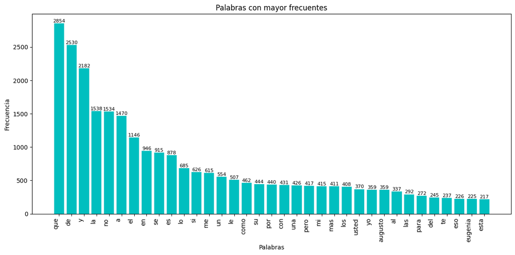

```python
import matplotlib.pyplot as plt
import numpy as np

def plot_word_histogram(freq_sorted_words, most_freq=35):
    # Limitar
    data = freq_sorted_words[:most_freq]

    # Separar palabras y frecuencias
    words = [item[0] for item in data]
    counts = [item[1] for item in data]

    # Crear
    plt.figure(figsize=(12, 6))
    bars = plt.bar(words, counts, color='#00BFBF')

    # Etiquetas
    for bar in bars:
        yval = bar.get_height()
        plt.text(bar.get_x() + bar.get_width()/2, yval + 0.5, int(yval),
                 ha='center', va='bottom', fontsize=8)

    # Titulos
    plt.xlabel("Palabras")
    plt.ylabel("Frecuencia")
    plt.title(f"Palabras con mayor frecuentes")
    plt.xticks(rotation=90, ha='right')
    plt.tight_layout()
    plt.show()

#  Graficar las 35 palabras más frecuentes
plot_word_histogram(freq_sorted_words, most_freq=35)
```

## Preguntas con respecto al libro 1

A continuación, se responderán las siguientes preguntas relacionadas con el texto procesado:

1. **¿Cuántas palabras hay en el texto?**  
   El *Libro 1* contiene un total de **56,820** palabras.
2. **¿Cuántas palabras diferentes (palabras únicas) hay en el texto?**  
   En el *Libro 1* se identificaron **7,788** palabras únicas.
3. **¿Cuántas son las palabras con frecuencia 1 (*hapax legomena*) en el texto?**  
   En el *Libro 1* existen **4,699** palabras que aparecen solo una vez.

Los resultados mencionados se imprimen en la siguiente línea de código.

```python
def count_words(input_str):
    words = input_str.split()   # separa por espacios
    return len(words)

def count_unique_words(text: str) -> int:
    words = text.split()
    unique_words = set(words)   # elimina duplicados
    return len(unique_words)
def count_hapax(text: str) -> int:
    freq = word_freq(text)   # diccionario palabra → frecuencia
    hapax = [w for w, c in freq.items() if c == 1]
    return len(hapax)

print("\n Número de palabras en el Libro 1:", count_words(cleaned_text))
print("\n Número de palabras únicas en el Libro 1:", count_unique_words(cleaned_text))
print("\n Número de hapax legomena en el Libro 1:", count_hapax(cleaned_text))
```

```
 Número de palabras en el Libro 1: 56820

 Número de palabras únicas en el Libro 1: 7788

 Número de hapax legomena en el Libro 1: 4699
```

# Libro 2

## Proceso de limpieza y obtención de resultados del Libro 2

Ahora bien, ya se cuenta con todas las funciones de limpieza y análisis previamente definidas, se procede a aplicarlas de manera secuencial al **Libro 2**.  
Este procedimiento permite optimizar el flujo de trabajo y evitar la repetición de pasos, lo que contribuye a que el documento sea más claro y conciso.

**El proceso incluye:**

- Convertir todo el contenido a minúsculas.
- Eliminar acentos.
- Reemplazar saltos de línea y tabulaciones.
- Suprimir caracteres especiales.

Una vez limpio el texto, se calcula la frecuencia de cada palabra y se ordenan los resultados de mayor a menor, para finalmente representarlos gráficamente, lo que facilita su observación visual y posterior interpretación.

Al igual que en el libro 1, en el libro 2 las palabras más frecuentes siguen siendo principalmente funcionales del español, como “de”, “que”, “la”, “y”, “a” y “el”, lo cual es habitual en textos narrativos en el español. Además, a diferencia del libro 1, en este caso aparecen con mayor fuerza artículos y pronombres vinculados a la narración de hechos, lo que sugiere diferencias en el estilo y en la forma de escritura de los autores.

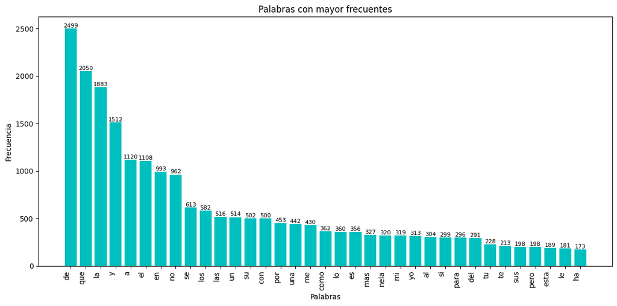

```python
# 0. Leer el nuevo archivo del libro 2
file_path = "/content/drive/MyDrive/MCDI/libro_2.txt"
with open(file_path, "r", encoding="utf-8") as f:
    text_2 = f.read()

# 1. Convertir el texto a minúsculas
text_lower_2 = text_lower_func(text_2)

# 2. texto sin acentos
text_no_accents_2 = remove_accents(text_lower_2)

# 3. Remueve caracteres especiales
text_no_special_chars_2 = remove_special_chars(text_no_accents_2)

# 4. Reemplazar saltos de línea
text_no_newlines_2 = replace_newlines(text_no_special_chars_2)

# 5. Reemplazar tabulaciones
text_no_tabs_2 = replace_tabs(text_no_newlines_2)

# 6. Quitar los stopwords en español
cleaned_text_2 = text_no_tabs_2

# 7. Calcular la frecuencia de palabras
freq_words_2 = word_freq(cleaned_text_2)

# 8. Ordenar de mayor a menor
freq_sorted_words_2 = sorted(freq_words_2.items(), key=lambda x: x[1], reverse=True)

# 9. Mostrar las 15 más frecuentes
freq_sorted_words_2[:35]

# 10. Graficar
plot_word_histogram(freq_sorted_words_2, most_freq=35)
```

## Preguntas con respecto al libro 2

Los resultados mencionados se imprimen en la siguiente línea de código.

```python
print("\n Número de palabras en el Libro 2:", count_words(cleaned_text_2))
print("\n Número de palabras únicas en el Libro 2:", count_unique_words(cleaned_text_2))
print("\n Número de hapax legomena en el Libro 2:", count_hapax(cleaned_text_2))
```

```
 Número de palabras en el Libro 2: 50540

 Número de palabras únicas en el Libro 2: 8496

 Número de hapax legomena en el Libro 2: 5213
```

# CONCLUSIONES

En conclusión, esta práctica permitió recorrer todo el proceso de análisis de texto, desde la preparación y limpieza de los archivos hasta la visualización de resultados mediante histogramas.

El análisis de frecuencias mostró que en ambos libros predominan las palabras funcionales propias del español.

Sin embargo, la comparación entre libros reveló los distintos estilos narrativos. Además, cada escritor tiene un sello particular en su manera de escribir.

# REFERENCIAS

Bahit, E. (2012). *Curso Python para principiantes*.

Bird, S., Klein, E., & Loper, E. (2009). *Natural language processing with Python: analyzing text with the natural language toolkit*. O'Reilly Media, Inc.

Hinojosa Gutiérrez, Á. P. (2011). *Introducción al lenguaje de programación de Python*.

**Documento en Colab** [enlace](https://colab.research.google.com/drive/1ve337YsJLLTVy_3tICaZpd8BDuIUKhTy?usp=sharing).